# Sentiment Analyisis in Crude Oil Markets

This project leverages on text data sourced from [Twitter](https://twitter.com/) in addition to Natural Language Processing packages in R (E.g. [qdap](https://www.rdocumentation.org/packages/qdap/versions/2.3.2) and [tidytext](https://www.rdocumentation.org/packages/tidytext/versions/0.2.0)) to perform basic Sentiment Analysis.

The objective will be to see if applying such methods to Twitter-sourced text data leads to any interesting insights. Future implementations might involve the integration of such findings with an algorithmic trading strategy to take positions based on market sentiment.

### 1. Importing Required Packages in R

```r
library(knitr)  # Export R Notebook to R Script
library(qdap)  # Quantitative Discourse Analysis Package
library(RCurl)  # For HTTP Requests
library(stringr)  # For String Manipulation
library(tidytext)  # Natural Language Processing package in R
library(tidyverse)  # For data wrangling
library(tm)  # Text Mining
library(twitteR)  # To connect to the Twitter API
library(wordcloud)  # Generation of Word Clouds
```

### 2. Querying Twitter Data into R

```r
# Store the required API keys for connection to Twitter
api_key <- "hBgUhFxipyNt2JT87QEGuV1Ok"
api_secret <- "kEkWlcKIC1nHamXMHOrYzZzsevGtnZ26j1XggoannDcvESRx9J"
access_token <- "898901988754153472-boY81BSVy95r26As36rYxzNX63C6ibl"
access_token_secret <- "obKPRXeSx6UiLUCQoirN95G2zt66TWepMbKQ032mzZFzL"

# Authenticate against the Twitter API
setup_twitter_oauth(api_key, api_secret, access_token, access_token_secret)
```

```
[1] "Using direct authentication"
```

```r
# Query tweets related to "#crudeoil"
crude_tweets <- searchTwitter(searchString = "#crudeoil", n = 1000, lang = "en")

# Examine the crude_tweets object
head(crude_tweets)
```

```
[[1]]
[1] "Nzz9rG5kFC: RT @aeberman12: Markets seem to view Iran crisis as a very short-term supply concern.\nBrent price increased +$3.19 to $65.20 but almost no…"

[[2]]
[1] "Nzz9rG5kFC: RT @aeberman12: Trade-weighted U.S. dollar (TWD) has fallen slightly from record level in early June.\nTWD week ending June 14 was +1% more…"

[[3]]
[1] "Nzz9rG5kFC: RT @aeberman12: \"If Mr. Trump’s real policy is Mr. Paul’s, then he should be honest with  Americans and return to the Obama nuclear deal. I…"

[[4]]
[1] "madronapartners: RT @aeberman12: Markets seem to view Iran crisis as a very short-term supply concern.\nBrent price increased +$3.19 to $65.20 but almost no…"

[[5]]
[1] "SERHATT21: RT @aeberman12: Trade-weighted U.S. dollar (TWD) has fallen slightly from record level in early June.\nTWD week ending June 14 was +1% more…"

[[6]]
[1] "oilbot123: RT @aeberman12: \"If Mr. Trump’s real policy is Mr. Paul’s, then he should be honest with  Americans and return to the Obama nuclear deal. I…"
```

```r
# Convert the raw queried data into a data.frame object
crude_df <- twListToDF(crude_tweets)

# Examine the data.frame object
str(crude_df)
```

```
'data.frame':   1000 obs. of  16 variables:
 $ text         : chr  "RT @aeberman12: Markets seem to view Iran crisis as a very short-term supply concern.\nBrent price increased +$"| __truncated__ "RT @aeberman12: Trade-weighted U.S. dollar (TWD) has fallen slightly from record level in early June.\nTWD week"| __truncated__ "RT @aeberman12: \"…
 $ favorited    : logi  FALSE FALSE FALSE FALSE FALSE FALSE ...
 $ favoriteCount: num  0 0 0 0 0 0 0 0 9 0 ...
 $ replyToSN    : chr  NA NA NA NA ...
 $ created      : POSIXct, format: "2019-06-22 19:59:37" "2019-06-22 19:59:11" "2019-06-22 19:39:40" "2019-06-22 19:30:44" ...
 $ truncated    : logi  FALSE FALSE FALSE FALSE FALSE FALSE ...
 $ replyToSID   : chr  NA NA NA NA ...
 $ id           : chr  "1142522548602585088" "1142522439521320960" "1142517530608558081" "1142515282050576384" ...
 $ replyToUID   : chr  NA NA NA NA ...
 $ statusSource : chr  "<a href=\"http://twitter.com/download/iphone\" rel=\"nofollow\">Twitter for iPhone</a>" "<a href=\"http://twitter.com/download/iphone\" rel=\"nofollow\">Twitter for iPhone</a>" "<a href=\"http://twitter.com/download/iphone\" rel=\"nofollow\">Twitter for iPhone</a>" "<a href=\…
 $ screenName   : chr  "Nzz9rG5kFC" "Nzz9rG5kFC" "Nzz9rG5kFC" "madronapartners" ...
 $ retweetCount : num  5 2 5 5 2 5 5 5 5 1 ...
 $ isRetweet    : logi  TRUE TRUE TRUE TRUE TRUE TRUE ...
 $ retweeted    : logi  FALSE FALSE FALSE FALSE FALSE FALSE ...
 $ longitude    : logi  NA NA NA NA NA NA ...
 $ latitude     : logi  NA NA NA NA NA NA ...
```

```r
View(crude_df)
```

### 3. Text Preprocessing

```r
# Remove all preceding "RT" characters in Retweeted tweets
crude_df$text <- gsub(pattern = "RT", replacement = "", crude_df$text)

# Remove all Twitter user handles in Retweets
crude_df$text <- gsub(pattern = "@\\w+", replacement = "", crude_df$text)

# Convert all tweets to lower case
crude_df$text <- tolower(crude_df$text)

# Remove punctuation
crude_df$text <- removePunctuation(crude_df$text)

# Remove quotation marks
crude_df$text <- gsub(pattern = '“', replacement = "", crude_df$text)

# Remove URL links
crude_df$text <- gsub("http\\w+", "", crude_df$text)

# Replace contractions
crude_df$text <- replace_contraction(crude_df$text)

# Examine the cleaned text data
crude_df$text[1:10]
```

```
 [1] "Markets seem to view iran crisis as a very shortterm supply concern brent price increased 319 to 6520 but almost no…"
 [2] "Tradeweighted us dollar twd has fallen slightly from record level in early june twd week ending june 14 was 1 more…"
 [3] "If mr trump’s real policy is mr paul’s then he should be honest with americans and return to the obama nuclear deal i…"
 [4] "Markets seem to view iran crisis as a very shortterm supply concern brent price increased 319 to 6520 but almost no…"
 [5] "Tradeweighted us dollar twd has fallen slightly from record level in early june twd week ending june 14 was 1 more…"
 [6] "If mr trump’s real policy is mr paul’s then he should be honest with americans and return to the obama nuclear deal i…"
 [7] "If mr trump’s real policy is mr paul’s then he should be honest with americans and return to the obama nuclear deal i…"
 [8] "If mr trump’s real policy is mr paul’s then he should be honest with americans and return to the obama nuclear deal i…"
 [9] "If mr trump’s real policy is mr paul’s then he should be honest with americans and return to the obama nuclear…"
[10] "Front 6 months open interest oi for crude oil options happy saturday clf crudeoil wti…"
```

```r
# Define a list of uninformative stop-words for removal
crude_stopwords <- c("crudeoil", "Crudeoil", "crude", "oil", "oott", stopwords("en"))

# Remove all stop words
crude_df$text <- removeWords(crude_df$text, crude_stopwords)

# Remove all whitespace
crude_df$text <- stripWhitespace(crude_df$text)

# Examine the text data without stop words
crude_df$text[1:10]
```

```
 [1] "Markets seem view iran crisis shortterm supply concern brent price increased 319 6520 almost …"
 [2] "Tradeweighted us dollar twd fallen slightly record level early june twd week ending june 14 1 …"
 [3] "If mr trump’s real policy mr paul’s honest americans return obama nuclear deal …"
 [4] "Markets seem view iran crisis shortterm supply concern brent price increased 319 6520 almost …"
 [5] "Tradeweighted us dollar twd fallen slightly record level early june twd week ending june 14 1 …"
 [6] "If mr trump’s real policy mr paul’s honest americans return obama nuclear deal …"
 [7] "If mr trump’s real policy mr paul’s honest americans return obama nuclear deal …"
 [8] "If mr trump’s real policy mr paul’s honest americans return obama nuclear deal …"
 [9] "If mr trump’s real policy mr paul’s honest americans return obama nuclear…"
[10] "Front 6 months open interest oi options happy saturday clf wti…"
```

The Twitter text data at this point appears to be sufficiently pre-processed. Next steps in the project will include basic analytics with wordclouds and ggplot, before moving onto Sentiment Analysis.

### 4. Exploratory Data Analysis with ggplot and wordcloud

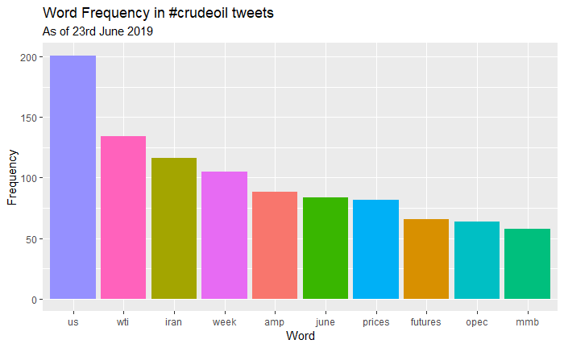

```r
# Explore the most common words in the data set
crude_df %>%
  unnest_tokens(word, text) %>%
  group_by(word) %>%
  count() %>%
  arrange(desc(n)) %>%
  head(n = 10) %>%
  ggplot(mapping = aes(x = reorder(word, desc(n)), y = n, fill = word)) +
    geom_col() +
    labs(
      title = "Word Frequency in #crudeoil tweets",
      subtitle = "As of 23rd June 2019",
      x = "Word",
      y = "Frequency"
    ) +
    theme(legend.position = "none")
```

As we can observe from this early exploration of the data, the most common word in tweets associated with crude oil are “us”, “wti” and “iran”. This corresponds to the geopolitical situation as of 23rd June 2019 where tensions between the United States and Iran are weighing heavily on the market’s view of the oil market.

```
transformation drops documentstransformation drops documents
```

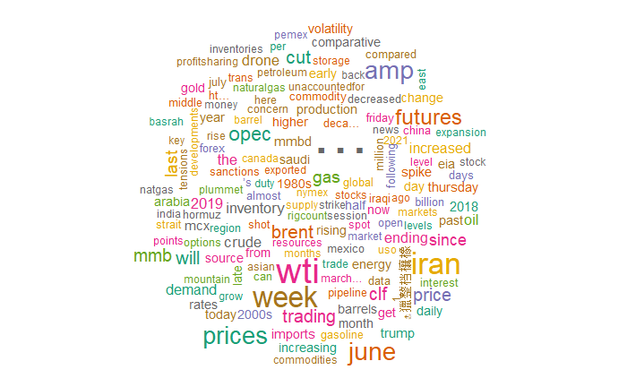

```r
# Generate a simple word cloud on the Twitter data
wordcloud(
  words = crude_df$text,
  min.freq = 15,
  colors = brewer.pal(8, "Dark2"),
  random.color = TRUE,
  max.words = 250
  )
```

The wordcloud visualization reiterates the salient points in the data: the most common words include “iran”, “prices”, “futures”, “june” and “wti” - likely indicating the effect that the US-Iran tensions is having on the futures market for Crude.

### 5. Basic Sentiment Analysis with qdap::polarity()

Next, apart from simple word counts, we want to roughly estimate the “polarity” or emotion of the collection of tweets. To do this, we use the polarity() function from the qdap package.

```r
# Define a Polarity Object for the set of #crudeoil tweets
crude_polarity <- polarity(crude_df$text)
```

[output not shown]

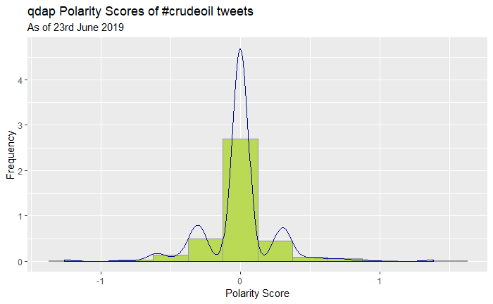

```r
# Visualize the polarity object with ggplot
ggplot(crude_polarity$all, aes(x = polarity, y = ..density..)) +
  geom_histogram(binwidth = 0.25, fill = "#bada55", colour = "grey60") +
  geom_density(color = "darkblue") +
  labs(
    title = "qdap Polarity Scores of #crudeoil tweets",
    subtitle = "As of 23rd June 2019",
    x = "Polarity Score",
    y = "Frequency"
  )
```

A rough analysis of all tweets in the dataset does not suggest that sentiment in this space skews either left or right. Most observations appear to return a polarity score of 0, although the mean does appear to tilt to the left (i.e. negativity).

Further analysis on sentiment will be attempted by joining a pre-loaded Lexicon of sentiment and repeating the analysis.

### 6. Preprocessing for tidytext

Another method of drawing sentiment from textual data involves using the tidytext package and its associated lexicons (E.g. NRC, AFINN and Bing). In this following section, we perform an inner-join of our crude data to the lexicons and attempt to draw further insights.

```r
# Load the Bing Lexicon
bing <- get_sentiments("bing")

# Store a character vector containing all tweets
tweet_vector <- crude_df$text

# Examine the vector
str(tweet_vector)
```

```
 chr [1:1000] "Tradeweighted us dollar twd fallen slightly record level early june twd week ending june 14 …" ...
```

```r
head(tweet_vector)
```

```
[1] "Tradeweighted us dollar twd fallen slightly record level early june twd week ending june 14 …"
[2] "Rates transporting cargoes saudi arabia china jumped almost 26000day thursday double …"
[3] "Rates transporting cargoes saudi arabia china jumped almost 26000day thursday double …"
[4] "Canadian crudebyrail exports rebounded april 2019 reach 236152 barrels per day bd 40 increase m…"
[5] "About 65 amp condensate passing strait hormuz went just five markets last year china india…"
[6] "About 65 amp condensate passing strait hormuz went just five markets last year china india…"
```

```r
tail(tweet_vector)
```

```
[1] "Soyabean soybeanmeal hipro poultryfeed cattlefeed soyoil feedmanufacturers promise purity v…"
[2] "Soyabean soybeanmeal hipro poultryfeed cattlefeed soyoil feedmanufacturers soyabeanoil healthy…"
[3] "Soyabean soybeanmeal hipro poultryfeed cattlefeed soyoil feedmanufacturers prefer soybeanmeal …"
[4] "Soyabean soybeanmeal hipro poultryfeed cattlefeed soyoil feedmanufacturers hipro soybeanmeal …"
[5] "Soyabean soybeanmeal hipro poultryfeed cattlefeed soyoil feedmanufacturers improve cattle heal…"
[6] "Soyabean soybeanmeal hipro poultryfeed cattlefeed soyoil feedmanufacturers improve …"
```

```r
# Convert the character vector into a Volatilte Corpus
tweet_corpus <- VCorpus(VectorSource(tweet_vector))

# Convert the corpus into a Document Term Matrix
tweet_dtm <- DocumentTermMatrix(tweet_corpus)
tweet_dtm_matrix <- as.matrix(tweet_dtm)

# Examine the Document Term Matrix
str(tweet_dtm_matrix)
```

```
 num [1:1000, 1:2441] 0 0 0 0 0 0 0 0 0 0 ...
 - attr(*, "dimnames")=List of 2
  ..$ Docs : chr [1:1000] "1" "2" "3" "4" ...
  ..$ Terms: chr [1:2441] "‘’’s" "‘big" "‘climateemergency’" "\200mwh" ...
```

Appropriately, we get a Document Term Matrix with 1000 rows (representing the 1000 tweets that were queried) and 2441 columns (representing 2441 unique terms that were found in the dataset).

```r
# Tidy the Document Term Matrix for tidytext analysis
tidy_tweets <- tidy(tweet_dtm)

# Examine the tidied dataset
str(tidy_tweets)
```

```
Classes ‘tbl_df’, ‘tbl’ and 'data.frame':   10277 obs. of  3 variables:
 $ document: chr  "1" "1" "1" "1" ...
 $ term    : chr  "dollar" "early" "ending" "fallen" ...
 $ count   : num  1 1 1 1 2 1 1 1 1 2 ...
```

```r
head(tidy_tweets)
```

| document | term | count |
| --- | --- | --- |
| 1 | dollar | 1 |
| 1 | early | 1 |
| 1 | ending | 1 |
| 1 | fallen | 1 |
| 1 | june | 2 |
| 1 | level | 1 |

```r
tail(tidy_tweets)
```

| document | term | count |
| --- | --- | --- |
| 1000 | hipro | 1 |
| 1000 | improve | 1 |
| 1000 | poultryfeed | 1 |
| 1000 | soyabean | 1 |
| 1000 | soybeanmeal | 1 |
| 1000 | soyoil | 1 |

The second stage of preprocessing gives us a “tidy dataset” i.e. a data structure that abides by “tidyverse” conventions. By having “term” as a column, this gives us the opportunity to join a sentiment lexicon in the next stage to draw insights about the sentiment of the dataset.

### 7. Sentiment Analysis with tidytext

```r
# Store the "Bing" lexicon from tidytext
bing <- get_sentiments(lexicon = "bing")

# Inner join the Bing lexicon to the Document Term Matrix and generate a Polarity Score
tweet_polarity_bing <-
  tidy_tweets %>%
  inner_join(bing, by = c("term" = "word")) %>%
  mutate(index = as.numeric(document)) %>%
  count(sentiment, index) %>%
  spread(sentiment, n, fill = 0) %>%
  mutate(polarity = positive - negative)

# Examine the mutated dataset
str(tweet_polarity_bing)
```

```
Classes ‘tbl_df’, ‘tbl’ and 'data.frame':   360 obs. of  4 variables:
 $ index   : num  1 8 13 16 17 18 19 20 21 22 ...
 $ negative: num  1 0 1 2 2 2 2 2 2 2 ...
 $ positive: num  0 1 0 0 1 1 1 1 1 0 ...
 $ polarity: num  -1 1 -1 -2 -1 -1 -1 -1 -1 -2 ...
```

```r
head(tweet_polarity_bing)
```

| index | negative | positive | polarity |
| --- | --- | --- | --- |
| 1 | 1 | 0 | -1 |
| 8 | 0 | 1 | 1 |
| 13 | 1 | 0 | -1 |
| 16 | 2 | 0 | -2 |
| 17 | 2 | 1 | -1 |
| 18 | 2 | 1 | -1 |

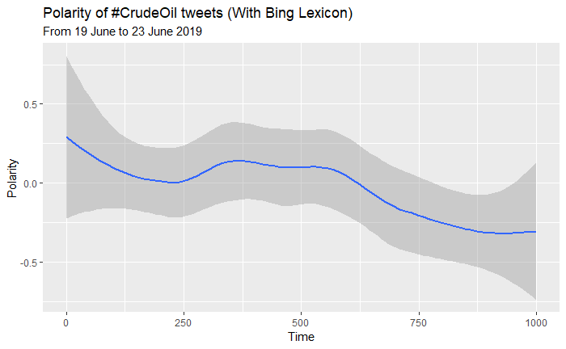

```r
# Plot Polarity Scores against Index
ggplot(data = tweet_polarity_bing, aes(rev(index), polarity)) +
  geom_smooth() +
  labs(
    title = "Polarity of #CrudeOil tweets (With Bing Lexicon)",
    subtitle = "From 19 June to 23 June 2019",
    x = "Time",
    y = "Polarity"
  )
```

First-stage analysis of the #crudeoil tweet data with the Bing lexicon returns a plot that is much more informative than the earlier analysis with qdap::polarity. Indexed by the tweet id (which is ordered in time), we see that sentiment over the last 4 days appears to have trended downwards.

This is not unsurprising: in the span of these 4 days, the crude oil market reacted strongly to news of [Iran shooting down a U.S. drone over the Straits of Hormuz, in addition to news concerning Trump’s willingness to approve military strikes on Iran](https://www.aljazeera.com/news/2019/06/iran-tensions-latest-updates-190621103437644.html). The threat of war has heavy implications on the supply of crude out of the Persian Gulf.

```r
# Store the "AFINN" lexicon from tidytext
afinn <- get_sentiments(lexicon = "afinn")

# Inner join the AFINN lexicon to the Document Term Matrix and generate a Polarity Score
tweet_polarity_afinn <-
  tidy_tweets %>%
  inner_join(afinn, by = c("term" = "word")) %>%
  mutate(index = as.numeric(document)) %>%
  count(value, index) %>%
  group_by(index) %>%
  summarize(polarity = sum(value * n))

# Examine the mutated dataset
str(tweet_polarity_afinn)
```

```
Classes ‘tbl_df’, ‘tbl’ and 'data.frame':   397 obs. of  2 variables:
 $ index   : num  1 4 8 10 12 14 15 16 17 18 ...
 $ polarity: num  -2 2 2 1 -1 -1 -1 1 3 3 ...
```

```r
head(tweet_polarity_afinn)
```

| index | polarity |
| --- | --- |
| 1 | -2 |
| 4 | 2 |
| 8 | 2 |
| 10 | 1 |
| 12 | -1 |
| 14 | -1 |

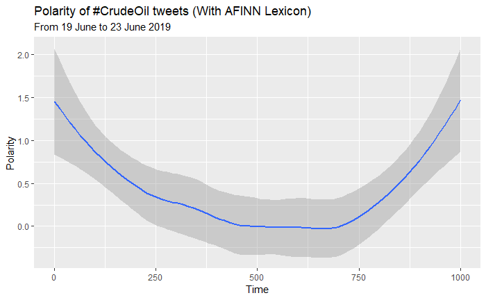

```r
# Plot Polarity Scores against Index
ggplot(data = tweet_polarity_afinn, aes(rev(index), polarity)) +
  geom_smooth() +
  labs(
    title = "Polarity of #CrudeOil tweets (With AFINN Lexicon)",
    subtitle = "From 19 June to 23 June 2019",
    x = "Time",
    y = "Polarity"
  )
```

Repeating the analysis with the AFINN Lexicon shows different results: sentiment appeared to fall earlier in time, but reversed the trend halfway and is now trending up.

This is another interpretation of the set of geopolitical events: with the Iran strike on the U.S. drone, market expectations of war might have increased - but with Trump’s confirmation of his decision to *call back* the strikes on Iran, the market may have expressed relief: hence the reversal in sentiment.

```r
# Store the "Loughran-Macdonald" Sentiment Lexicon from tidytext
loughran <- get_sentiments(lexicon = "loughran")

# Inner join the Bing lexicon to the Document Term Matrix and generate a Polarity Score
tweet_polarity_loughran <-
  tidy_tweets %>%
  inner_join(loughran, by = c("term" = "word")) %>%
  mutate(index = as.numeric(document)) %>%
  group_by(sentiment) %>%
  summarize(count = sum(count))

# Examine the mutated dataset
str(tweet_polarity_loughran)
```

```
Classes ‘tbl_df’, ‘tbl’ and 'data.frame':   5 obs. of  2 variables:
 $ sentiment: chr  "constraining" "litigious" "negative" "positive" ...
 $ count    : num  7 43 270 102 105
```

```r
head(tweet_polarity_loughran)
```

| sentiment | count |
| --- | --- |
| constraining | 7 |
| litigious | 43 |
| negative | 270 |
| positive | 102 |
| uncertainty | 105 |

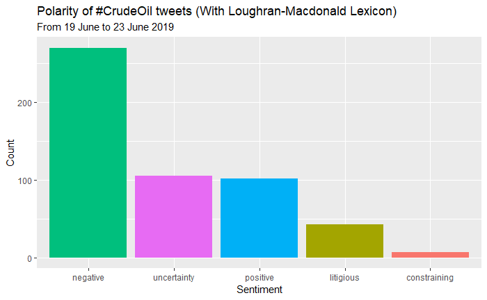

```r
# Plot a distribution of sentiments
ggplot(tweet_polarity_loughran, aes(x = reorder(sentiment, desc(count)), y = count, fill = sentiment)) +
  geom_col() +
  labs(
    title = "Polarity of #CrudeOil tweets (With Loughran-Macdonald Lexicon)",
    subtitle = "From 19 June to 23 June 2019",
    x = "Sentiment",
    y = "Count"
  ) +
  theme(legend.position = "none")
```

A final analysis with the Loughran-Macdonald Sentiment Lexicon shows a few more interesting insights. Sentiment across the 4-day period appear to be predominantly negative, with the next most apparent sentiment being “uncertainty”.

Again, such numerical findings correspond closely to the geopolitical situation at hand. Geopolitical risks such as a military conflict between the U.S. and Iran have heavy consequences on the financial and physical markets surrounding crude oil.

### 8. Comparison Clouds, Commonality Clouds and Pyramind Plots

In this final section, we split the tweet data into Positive and Negative baskets and draw out the most frequent terms per category.

To do so, we structure the data as a Term Document Matrix instead of a Document Term Matrix as a we did before.

```r
# Extract all "positive-sentiment" tweets and collapse into a single string
pos_terms <-
  crude_df %>%
  mutate(polarity = polarity(text)$all$polarity) %>%
  filter(polarity > 0) %>%
  pull(text) %>%
  paste(collapse = " ")

# View the joined string
substr(pos_terms, 1, 100)
```

```
[1] "Here dealerintermediary cot report majors enjoy saturday clf crudeo… Here dealerintermediary cot rep"
```

```r
# Extract all "negative-sentiment" tweets and collapse into a single string
neg_terms <-
  crude_df %>%
  mutate(polarity = polarity(text)$all$polarity) %>%
  filter(polarity < 0) %>%
  pull(text) %>%
  paste(collapse = " ")

# View the joined string
substr(neg_terms, 1, 100)
```

```
[1] "Tradeweighted us dollar twd fallen slightly record level early june twd week ending june 14 … Could "
```

```r
# Concatenate the two strings into a vector with 2 elements
all_terms <- c(pos_terms, neg_terms)

# Convert the vector into a Corpus
corpus_all_terms <- VCorpus(VectorSource(all_terms))

# Convert the Corpus into a TermDocumentMatrix
tdm_all_terms <- TermDocumentMatrix(
  corpus_all_terms,
  control = list(
    weighting = weightTf,
    removePunctuation = TRUE
  )
)

# Convert the TDM into an R matrix object
matrix_all_terms <- as.matrix(tdm_all_terms)
colnames(matrix_all_terms) <- c("Positive", "Negative")

# View the TDM Matrix
tail(matrix_all_terms)
```

```
         Docs
Terms     Positive Negative
  yields         1        0
  york           0        1
  you            8        0
  youtube        1        0
  zerodha        2        0
  zinc           1        0
```

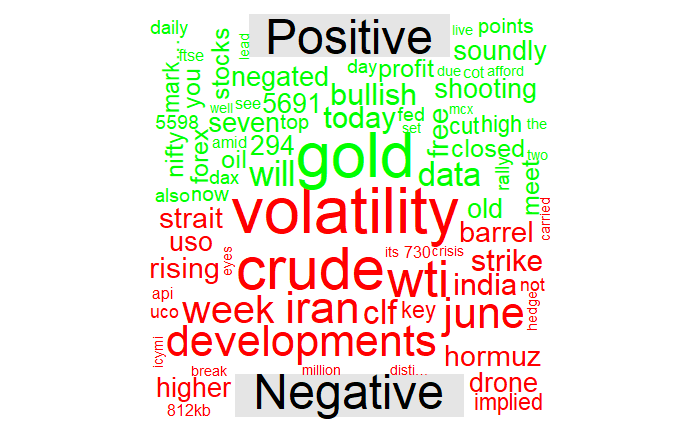

```r
# Plot a Comparison Cloud with the tidied TDM
comparison.cloud(matrix_all_terms, colors = c("green", "red"))
```

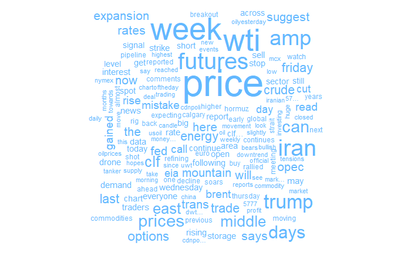

```r
commonality.cloud(matrix_all_terms, colors = "steelblue1")
```

Plotting both a Comparison Cloud and a Commonality Cloud shows a number of things: for instance, negative tweets are associated with words such as “iran”, “volatility”, “strait” and “strike” - another perspective to market sentiment vis-a-vis geopolitics in the Strait of Hormuz.

Positive tweets are associated with “fed”, “gold”, “bullish” and “stocks”: a likely result of discussions around the Federal Reserve’s dovish stance on interest rates and its correlated bullish effect on commodity markets. (A lower USD environment makes commodities priced in the currency *relatively less expensive* thus boosting demand)

Lastly, the commonality cloud tells us that some of the most common words occurring in both negative and positive #crudeoil tweets involve “price”, “trump”, “futures” and “wti”. These are relative neutral terms describing things moving the market and are thus expected in the commonality cloud.

```r
# Create a data.frame containing 25 of the most common terms to compare
top15_terms <-
  matrix_all_terms %>%
  as_tibble(rownames = "word") %>%
  filter_all(all_vars(. > 0)) %>%
  mutate(difference = Positive - Negative) %>%
  top_n(15, wt = difference) %>%
  arrange(desc(difference))

# Examine the top 25 terms
head(top15_terms)
```

| word | Positive | Negative | difference |
| --- | --- | --- | --- |
| will | 17 | 4 | 13 |
| data | 14 | 2 | 12 |
| bullish | 12 | 1 | 11 |
| today | 13 | 2 | 11 |
| closed | 9 | 1 | 8 |
| downtrend | 9 | 1 | 8 |

```
[1] 5.1 4.1 2.1 2.1
```

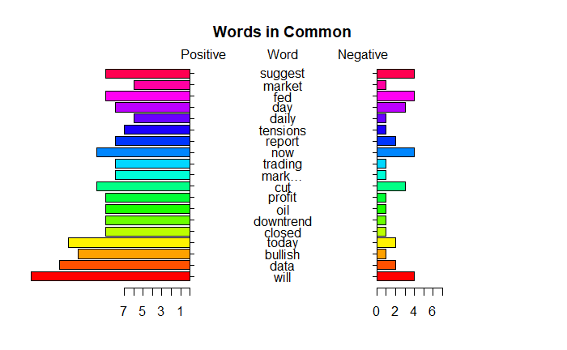

```r
# Create a Pyramid Plot to visualize the differences
library(plotrix)

pyramid.plot(
  top15_terms$Positive,
  top15_terms$Negative,
  labels = top15_terms$word,
  top.labels = c("Positive", "Word", "Negative"),
  main = "Words in Common",
  unit = NULL,
  gap = 10,
  space = 0.2
)
```

Finally, the pyramid plot gives us some insight into the “net emotion” of particular words: for instance, we can see that “bullish” occurs much more frequently in Positive tweets than in Negative ones. Interestingly, the word “downtrend” appears much more often in Positive tweets than in Negative ones as well.

### 9. Word Networks with qdap

A final form of analysis can tell us what words are most associated with a pre-defined word. We do this with the word_associate() function in qdap which can generate network graphs and/or word clouds around this form of analysis.

```r
# Create a Word Network plot with qdap'
word_associate(
  crude_df$text,
  match.string = c("trump"),
  stopwords = c("crude", stopwords("en")),
  wordcloud = TRUE,
  cloud.colors = c("gray85", "darkred"),
  nw.label.proportional = TRUE
  )
```

| row | group | unit | text |
| --- | --- | --- | --- |
| 137 | all | 137 | Crude staged dramatic turnaround last 48 hours can trump afford continue … |
| 141 | all | 141 | surges trump says iran made big mistake |
| 161 | all | 161 | Crude staged dramatic turnaround last 48 hours can trump afford continue … |
| 175 | all | 175 | surges trump says iran made big mistake |
| 177 | all | 177 | Crude staged dramatic turnaround last 48 hours can trump afford continue … |
| 189 | all | 189 | Coming 730 pm approving military strike iran donald trump changes mind amp abruptly pulls back … |
| 211 | all | 211 | Coming 730 pm approving military strike iran donald trump changes mind amp abruptly pulls back … |
| 214 | all | 214 | Coming 730 pm approving military strike iran donald trump changes mind amp abruptly pulls back … |
| 225 | all | 225 | Coming 730 pm approving military strike iran donald trump changes mind amp abruptly pulls ba… |
| 229 | all | 229 | Crude intraday gann levels trading money futures gann markets traders eia opec trump china… |

[output cut: 25 more lines]

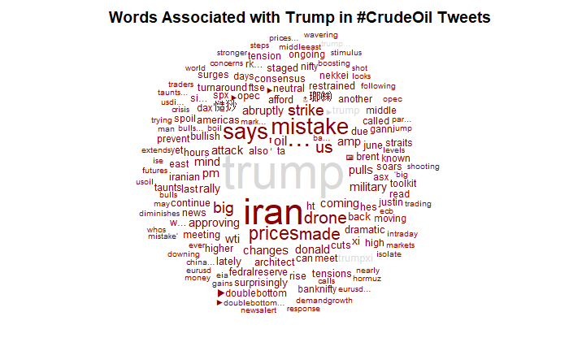

```r
title(main = "Words Associated with Trump in #CrudeOil Tweets")
```

```r
# Create a Word Network plot with qdap'
word_associate(
  crude_df$text,
  match.string = c("fed"),
  stopwords = c("crude", stopwords("en")),
  wordcloud = TRUE,
  cloud.colors = c("gray85", "darkred"),
  nw.label.proportional = TRUE
  )
```

| row | group | unit | text |
| --- | --- | --- | --- |
| 332 | all | 332 | United states china federal reserves hint lower rates stockmarketnews stock stockmarket nse bse… |
| 435 | all | 435 | You supportive stocks data fed indicating will cut rates shooting drone” olivi… |
| 554 | all | 554 | You supportive stocks data fed indicating will cut rates shooting drone” olivi… |
| 565 | all | 565 | Crude prices rallied geopolitical risks fed rate cut signal read … |
| 571 | all | 571 | Crude prices rallied geopolitical risks fed rate cut signal read … |
| 583 | all | 583 | You supportive stocks data fed indicating will cut rates shooting drone” olivi… |
| 602 | all | 602 | You supportive stocks data fed indicating will cut rates shooting drone” olivi… |
| 606 | all | 606 | You supportive stocks data fed indicating will cut rates shooting drone” olivi… |
| 609 | all | 609 | You supportive stocks data fed indicating will cut rates shooting drone” olivi… |
| 610 | all | 610 | You supportive stocks data fed indicating will cut rates shooting drone” olivi… |

[output cut: 8 more lines]

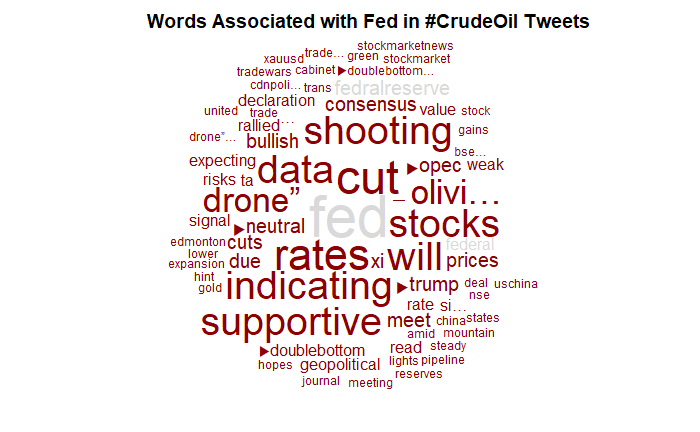

```r
title(main = "Words Associated with Fed in #CrudeOil Tweets")
```

### 10. Final Conclusions

This project attempted to leverage on key NLP libraries in R to derive new insights about market sentiment in the Crude Oil market.

Interestingly, we note that *price action* for Crude Oil in this timeframe was *overwhelmingly bullish*. (Note only was there the looming threat of war cutting off crude supplies, but the Fed’s dovish outlook also provided support for prices). This suggests that a naive interpretation of using negative sentiment to take bearish positions is overwhelmingly simplistic.

Future projects could involve the transformation of such sentiment data into an algorithmic trading strategy with packages such as ‘quanstrat’.

```r
# Export the analysis to an R Script
purl("crude-oil-sentiment-analysis.Rmd")
```

```
processing file: crude-oil-sentiment-analysis.Rmd
```

[output not shown]

```
output file: crude-oil-sentiment-analysis.R
```

```
[1] "crude-oil-sentiment-analysis.R"
```